# Project1_presidents_inauguation

Hongyang Yang-hy2500

September 19, 2017

# Section 0: check and install needed packages. Load the libraries and functions.

```r
#packages.used=c("rvest", "tibble", "qdap",
#                "sentimentr", "gplots", "dplyr",
#                "tm", "syuzhet", "factoextra",
#                "beeswarm", "scales", "RColorBrewer",
#                "RANN", "tm", "topicmodels","wordcloud",
#                "RColorBrewer","tydytext")

# check packages that need to be installed.
#packages.needed=setdiff(packages.used,
#                        intersect(installed.packages()[,1],
#                                  packages.used))
# install additional packages
#if(length(packages.needed)>0){
#  install.packages(packages.needed, dependencies = TRUE)
#}


library(wordcloud)
library(RColorBrewer)
library(dplyr)
library(tidytext)

# load packages
library("rvest")
library("tibble")
library("qdap")
library("sentimentr")
library("gplots")
library("dplyr")
library("tm")
library("syuzhet")
library("factoextra")
library("beeswarm")
library("scales")
library("RColorBrewer")
library("RANN")
library("tm")
library("topicmodels")
library("wordcloud")
library("RColorBrewer")
library("tidytext")

library("SnowballC")
library("wordnet")
library("ggplot2")
library("qdap")
library("NLP")
library("openNLP")
library("cluster")
library("fpc")


source("../lib/plotstacked.R")
source("../lib/speechFuncs.R")
```

This notebook was prepared with the following environmental settings.

```r
print(R.version)
```

```
##                _
## platform       x86_64-w64-mingw32
## arch           x86_64
## os             mingw32
## system         x86_64, mingw32
## status
## major          3
## minor          4.1
## year           2017
## month          06
## day            30
## svn rev        72865
## language       R
## version.string R version 3.4.1 (2017-06-30)
## nickname       Single Candle
```

# Section 1: Data Prepreation

## Step 1: scrap speech URLs from http://www.presidency.ucsb.edu/.

Following the example of [Jerid Francom](http://francojc.github.io/web-scraping-with-rvest/), we used [Selectorgadget](http://selectorgadget.com/) to choose the links we would like to scrap. For this project, we selected all inaugural addresses of past presidents

```r
### Inauguaral speeches
main.page <- read_html(x = "http://www.presidency.ucsb.edu/inaugurals.php")
# Get link URLs
# f.speechlinks is a function for extracting links from the list of speeches.
inaug=f.speechlinks(main.page)
#head(inaug)
as.Date(inaug[,1], format="%B %e, %Y")
```

```
##  [1] "1789-04-30" "1793-03-04" "1797-03-04" "1801-03-04" "1805-03-04"
##  [6] "1809-03-04" "1813-03-04" "1817-03-04" "1821-03-04" "1825-03-04"
## [11] "1829-03-04" "1833-03-04" "1837-03-04" "1841-03-04" "1845-03-04"
## [16] "1849-03-05" "1853-03-04" "1857-03-04" "1861-03-04" "1865-03-04"
## [21] "1869-03-04" "1873-03-04" "1877-03-05" "1881-03-04" "1885-03-04"
## [26] "1889-03-04" "1893-03-04" "1897-03-04" "1901-03-04" "1905-03-04"
## [31] "1909-03-04" "1913-03-04" "1917-03-04" "1921-03-04" "1925-03-04"
## [36] "1929-03-04" "1933-03-04" "1937-01-20" "1941-01-20" "1945-01-20"
## [41] "1949-01-20" "1953-01-20" "1957-01-21" "1961-01-20" "1965-01-20"
## [46] "1969-01-20" "1973-01-20" "1977-01-20" "1981-01-20" "1985-01-21"
## [51] "1989-01-20" "1993-01-20" "1997-01-20" "2001-01-20" "2005-01-20"
## [56] "2009-01-20" "2013-01-21" "2017-01-20" NA
```

```r
inaug=inaug[-nrow(inaug),] # remove the last line, irrelevant due to error.
```

## Step 2: Using speech metadata posted on http://www.presidency.ucsb.edu/, we prepared CSV data sets for the speeches we will scrap.

```r
inaug.list=read.csv("../data/inauglist.csv", stringsAsFactors = FALSE)
```

## Step 3: we prepared CSV data sets for presidents’ perosnality, education background, and economic recession.

http://thesixteentypes.tumblr.com/post/60372674743/personality-types-of-all-us-presidents https://en.wikipedia.org/wiki/List_of_recessions_in_the_United_States#Great_Depression_onward

If the president is introverted dominated set the personality to -1, extroverted dominated set the personality to 1. for example, Barack Obama is ENFP-Extraversion (E), Intuition (N), Thinking (T), Perception (P), that means he has an extroverted dominated personality.

If the inaugral speech happened during an economic recession, set the recession to 1. for example, the 2008 financial crisis happened during Dec 2007 – June 2009, Barack Obama delivered his 1st term inaugural speech on Jan, 2009. So his inaugural speech happened during an economic recession.

```r
personality_info=read.csv("../data/personality_info.csv", stringsAsFactors = FALSE,header=TRUE)


personality=personality_info$Personality
recession=personality_info$Recession

inaug.list=cbind(inaug.list,personality,recession)
```

We assemble all scrapped speeches into one list. Note here that we don’t have the full text yet, only the links to full text transcripts.

## Step 4: scrap the texts of speeches from the speech URLs.

```r
inaug.list$type=c(rep("inaug", nrow(inaug.list)))
inaug.list=cbind(inaug.list, inaug)
```

Based on the list of speeches, we scrap the main text part of the transcript’s html page. For simple html pages of this kind, [Selectorgadget](http://selectorgadget.com/) is very convenient for identifying the html node that `rvest` can use to scrap its content. For reproducibility, we also save our scrapped speeches into our local folder as individual speech files.

```r
# Loop over each row in speech.list
inaug.list$fulltext=NA
for(i in seq(nrow(inaug.list))) {
  text <- read_html(inaug.list$urls[i]) %>% # load the page
    html_nodes(".displaytext") %>% # isloate the text
    html_text() # get the text
  inaug.list$fulltext[i]=text
  # Create the file name
  filename <- paste0("../data/fulltext/",
                     inaug.list$type[i],
                     inaug.list$File[i], "-",
                     inaug.list$Term[i], ".txt")
  sink(file = filename) %>% # open file to write
  cat(text)  # write the file
  sink() # close the file
}
```

## Step 5: data Processing — generate list of sentences

We will use sentences as units of analysis for this project, as sentences are natural languge units for organizing thoughts and ideas. For each extracted sentence, we apply sentiment analysis using [NRC sentiment lexion](http://saifmohammad.com/WebPages/NRC-Emotion-Lexicon.htm). “The NRC Emotion Lexicon is a list of English words and their associations with eight basic emotions (anger, fear, anticipation, trust, surprise, sadness, joy, and disgust) and two sentiments (negative and positive). The annotations were manually done by crowdsourcing.”

We assign an sequential id to each sentence in a speech (`sent.id`) and also calculated the number of words in each sentence as *sentence length* (`word.count`).

```r
sentence.list=NULL
for(i in 1:nrow(inaug.list)){
  sentences=sent_detect(inaug.list$fulltext[i],
                        endmarks = c("?", ".", "!", "|",";"))
  if(length(sentences)>0){
    emotions=get_nrc_sentiment(sentences)
    word.count=word_count(sentences)
    # colnames(emotions)=paste0("emo.", colnames(emotions))
    # in case the word counts are zeros?
    emotions=diag(1/(word.count+0.01))%*%as.matrix(emotions)
    sentence.list=rbind(sentence.list,
                        cbind(inaug.list[i,-ncol(inaug.list)],
                              sentences=as.character(sentences),
                              word.count,
                              emotions,
                              sent.id=1:length(sentences)
                              )
    )
  }
}
```

Some non-sentences exist in raw data due to erroneous extra end-of sentence marks.

```r
sentence.list=
  sentence.list%>%
  filter(!is.na(word.count))
```

# Section 2: What words can Presidents’ personality tell us?

## Words/Sentenses analysis

First, let’s calculate extroverted v.s. introverted total sentenses, total words, and average words per sentenses

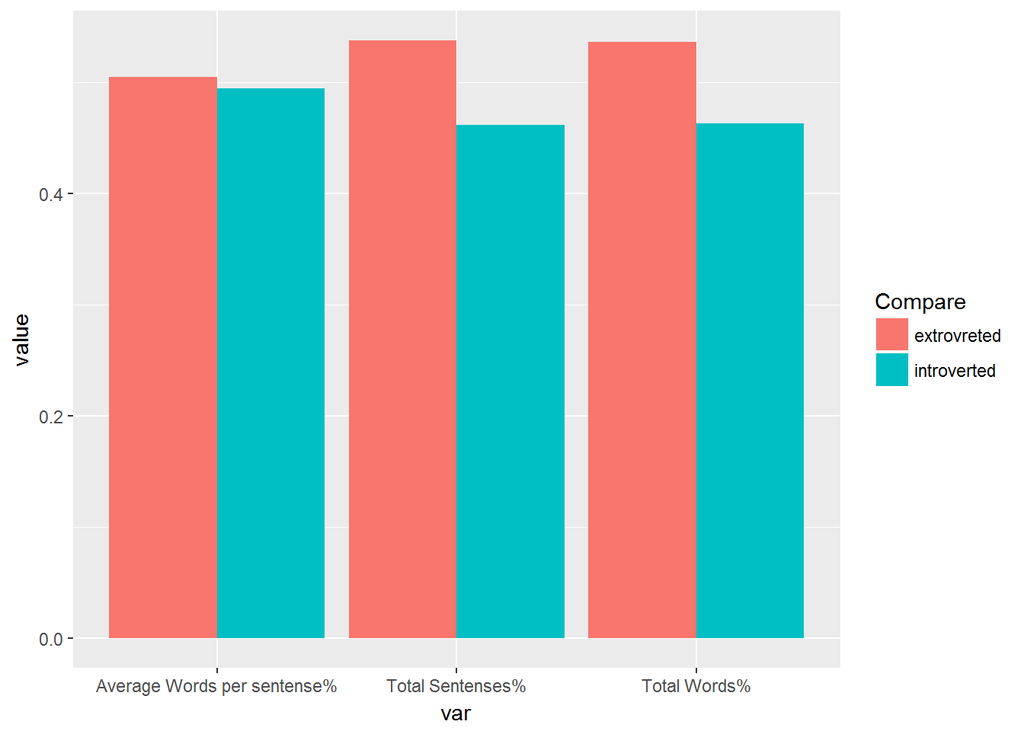

```r
extroverted_list=sentence.list[sentence.list$personality==1,]
introverted_list=sentence.list[sentence.list$personality==-1,]

# number of sentences
extrovreted_sentenses<-tapply(extroverted_list$sentences, extroverted_list$File, length)
 # average words per sentence
extrovreted_average_words<-round(tapply(extroverted_list$word.count, extroverted_list$File, mean),0)
extrovreted_words<-tapply(extroverted_list$word.count, extroverted_list$File, sum)
extrovreted_count<-data.frame(extrovreted_sentenses, extrovreted_average_words, extrovreted_words)

introverted_sentenses<-tapply(introverted_list$sentences, introverted_list$File, length)
 # average words per sentence
introverted_average_words<-round(tapply(introverted_list$word.count, introverted_list$File, mean),0)
introverted_words<-tapply(introverted_list$word.count, introverted_list$File, sum)
introverted_count<-data.frame(introverted_sentenses, introverted_average_words, introverted_words)


e=colMeans(extrovreted_count)
i=colMeans(introverted_count)
dt=matrix(c(rep("extrovreted",3),rep("introverted",3)),nrow=6,ncol=1)
total_sentenses=e[[1]]+i[[1]]
total_words=e[[3]]+i[[3]]
total_avg_words=e[[2]]+i[[2]]

dt=as.data.frame(dt)
colnames(dt)<-"Compare"
dt$var<-c(rep(c("Total Sentenses%","Total Words%","Average Words per sentense%"),2))
dt$value<-c(e[[1]]/total_sentenses,e[[3]]/total_words,e[[2]]/total_avg_words
            ,i[[1]]/total_sentenses,i[[3]]/total_words,i[[2]]/total_avg_words)

#png('../figs/Compare.png')
ggplot(dt, aes(x = var, y = value, fill = Compare))+
   geom_bar(stat="identity", position=position_dodge())
```

```r
#dev.off()
```

We can briefly conclude that an extroverted personality dominated president is more talkative than an introverted personality dominated president.

## Clustering analysis

Second, extroverted people are usually easy to identify and compare, so let’s use Kmeans to cluster extroverted presidents’ speeches to see if any presidents have the same talking style.

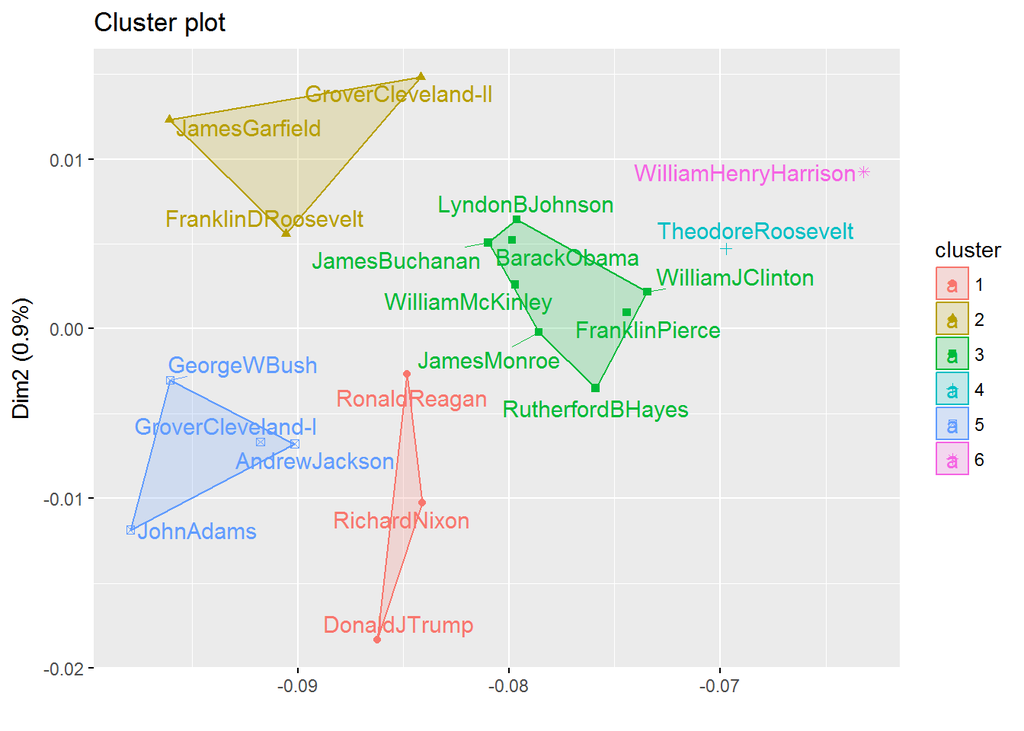

```r
#extroverted
presid.summary=tbl_df(extroverted_list)%>%
  #filter(File%in%sentence.list[sentence.list$personality==1,])%>%
  #group_by(paste0(type, File))%>%
  group_by(File)%>%
  summarise(
    anger=mean(anger),
    anticipation=mean(anticipation),
    disgust=mean(disgust),
    fear=mean(fear),
    joy=mean(joy),
    sadness=mean(sadness),
    surprise=mean(surprise),
    trust=mean(trust)
    #negative=mean(negative),
    #positive=mean(positive)
  )

presid.summary=as.data.frame(presid.summary)
rownames(presid.summary)=as.character((presid.summary[,1]))
km.res=kmeans(presid.summary[,-1], iter.max=200,
              6)
#png('../figs/fviz_cluster.png')
fviz_cluster(km.res,
             stand=F, repel= TRUE,
             data = presid.summary[,-1], xlab="", xaxt="n",
             show.clust.cent=FALSE)
```

I would say that Donald Trump and Richard Nixon have the same talking style, they are common in their ambition, Paranoia, and Media Distrust. They are both alpha male, have strange behavior and unwelcomed by most people.

## Visualize president’s sentense

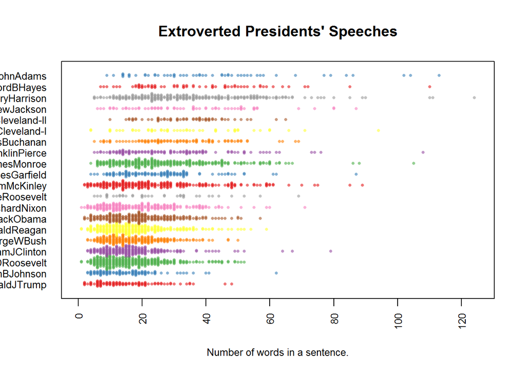

```r
extroverted_list$File=factor(extroverted_list$File)
extroverted_list$FileOrdered=reorder(extroverted_list$File,
                                  extroverted_list$word.count,
                                  mean,
                                  order=T)

#png('../figs/beeswarm_extroverted.png')

beeswarm(word.count~FileOrdered,
         data=extroverted_list,
         horizontal = TRUE,
         pch=16, col=alpha(brewer.pal(9, "Set1"), 0.6),
         cex=0.55, cex.axis=0.8, cex.lab=0.8,
         spacing=5/nlevels(extroverted_list$FileOrdered),
         las=2, ylab="", xlab="Number of words in a sentence.",
         main="Extroverted Presidents' Speeches")
```

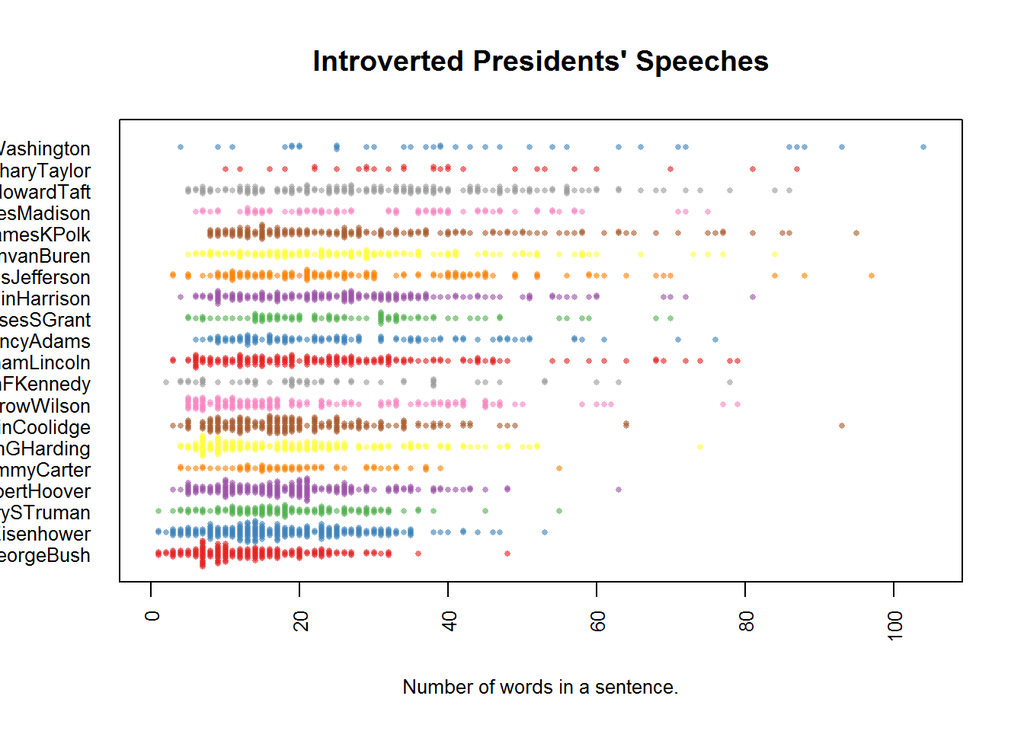

```r
introverted_list$File=factor(introverted_list$File)
introverted_list$FileOrdered=reorder(introverted_list$File,
                                  introverted_list$word.count,
                                  mean,
                                  order=T)
#png('../figs/beeswarm_introverted.png')

beeswarm(word.count~FileOrdered,
         data=introverted_list,
         horizontal = TRUE,
         pch=16, col=alpha(brewer.pal(9, "Set1"), 0.6),
         cex=0.55, cex.axis=0.8, cex.lab=0.8,
         spacing=5/nlevels(introverted_list$FileOrdered),
         las=2, ylab="", xlab="Number of words in a sentence.",
         main="Introverted Presidents' Speeches")
```

We notice that there are only one sentenses that are longer than 100 words in introverted presidents’ speeches, but there are few sentenses that are longer than 100 words in extrovered presidents’ speeches.

## What words did extroverted/introverted Presidents say?

```r
folder.path="../data/fulltext/"
speeches=list.files(path = folder.path, pattern = "*.txt")

#only get inaugural speeches
speeches=speeches[substr(speeches, 1, 5)=='inaug']

prez.out=substr(speeches, 6, nchar(speeches)-4)

introverted_index=NULL
speeches.president=substr(speeches, 6, nchar(speeches)-6)


#length.speeches=rep(NA, length(speeches))
ff.all<-Corpus(DirSource(folder.path,encoding="UTF-8"))
ff.all<-tm_map(ff.all, stripWhitespace)
ff.all<-tm_map(ff.all, content_transformer(tolower))
ff.all<-tm_map(ff.all, removeWords, stopwords("english"))
ff.all<-tm_map(ff.all, removeWords, character(0))
ff.all<-tm_map(ff.all, removePunctuation)

dtm <- DocumentTermMatrix(ff.all,
                          control = list(weighting =
                                           function(x)
                                             weightTfIdf(x, normalize =
                                                           FALSE),
                                         stopwords = TRUE))
ff.dtm=tidy(dtm)

#tdm.overall=summarise(group_by(tdm.tidy, term), sum(count))
```

```r
#match speeches to personality
personality.list=data.frame(File=inaug.list$File,Term=inaug.list$Term,personality=inaug.list$personality)

speeches.personality=cbind(personality.list[order(personality.list$File),],prez.out)

personality.index=which(speeches.personality$personality==1)
```

Let’s compare some famous extroverted and introverted presidents’ words. Do you think an extroverted president is more likely to use positive emotion words, and an introverted president is more likely to use rational or negative emotion words?

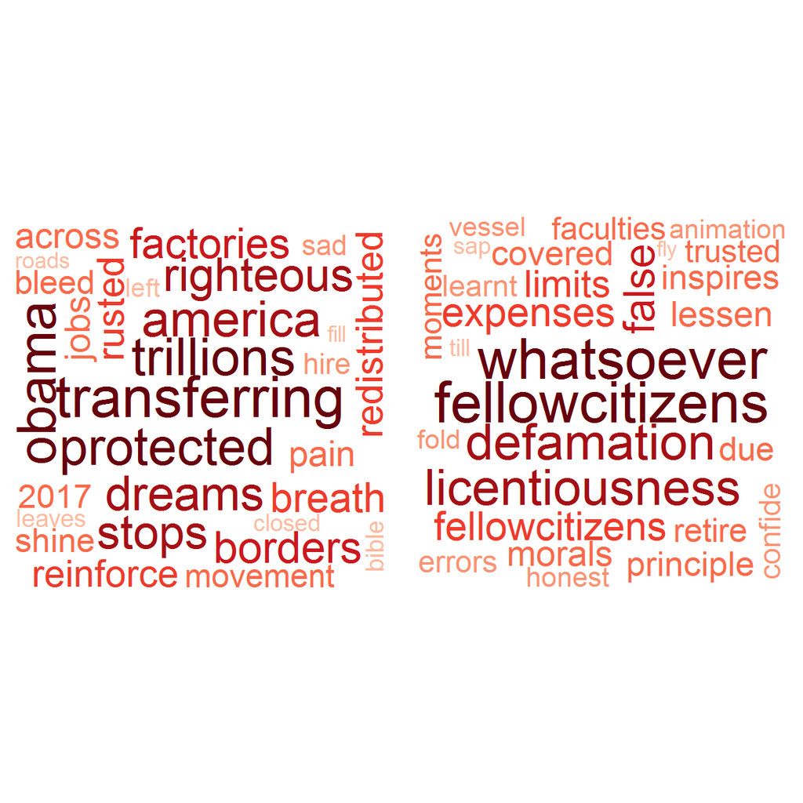

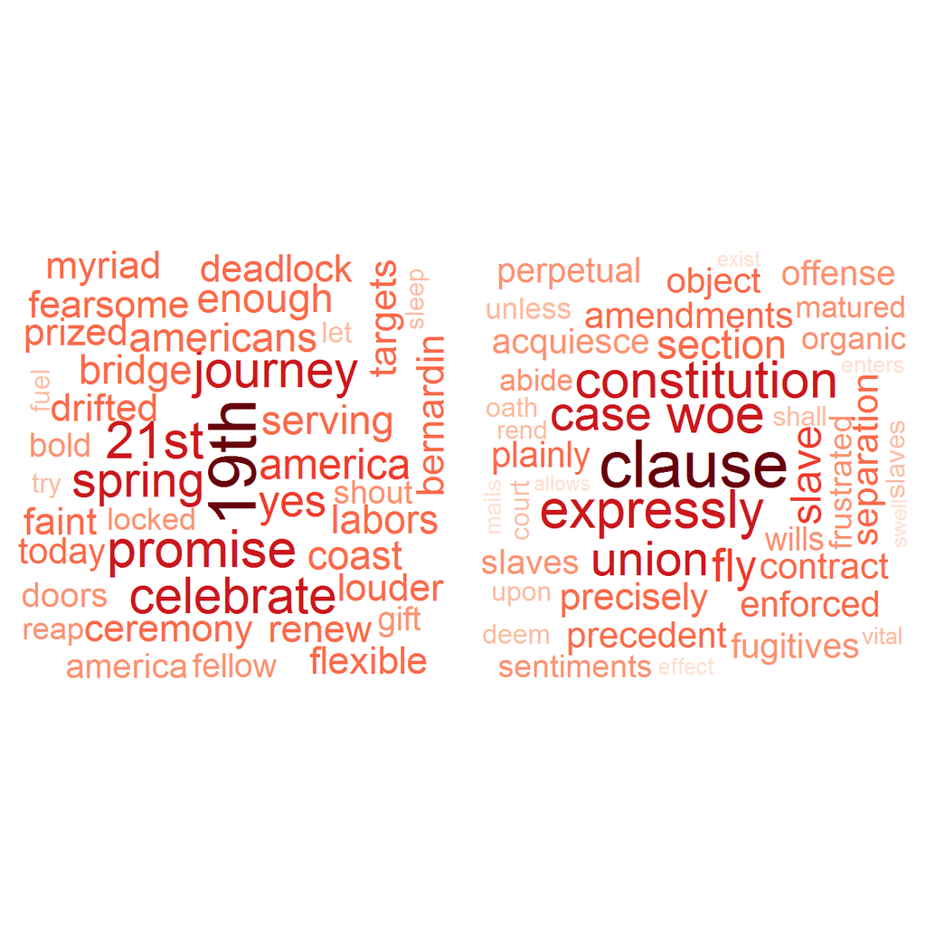

## Sentiment Analysis of Inauguration speeches

In the sentiment analysis part, we want to measure what is the proportion of the sentiment was positive or negative during the whole speech process.

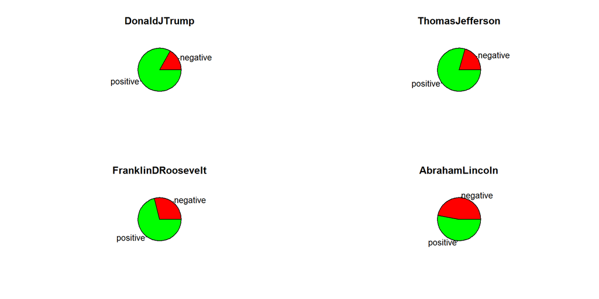

## Compare of extroverted/introverted presidents’ emotions in general

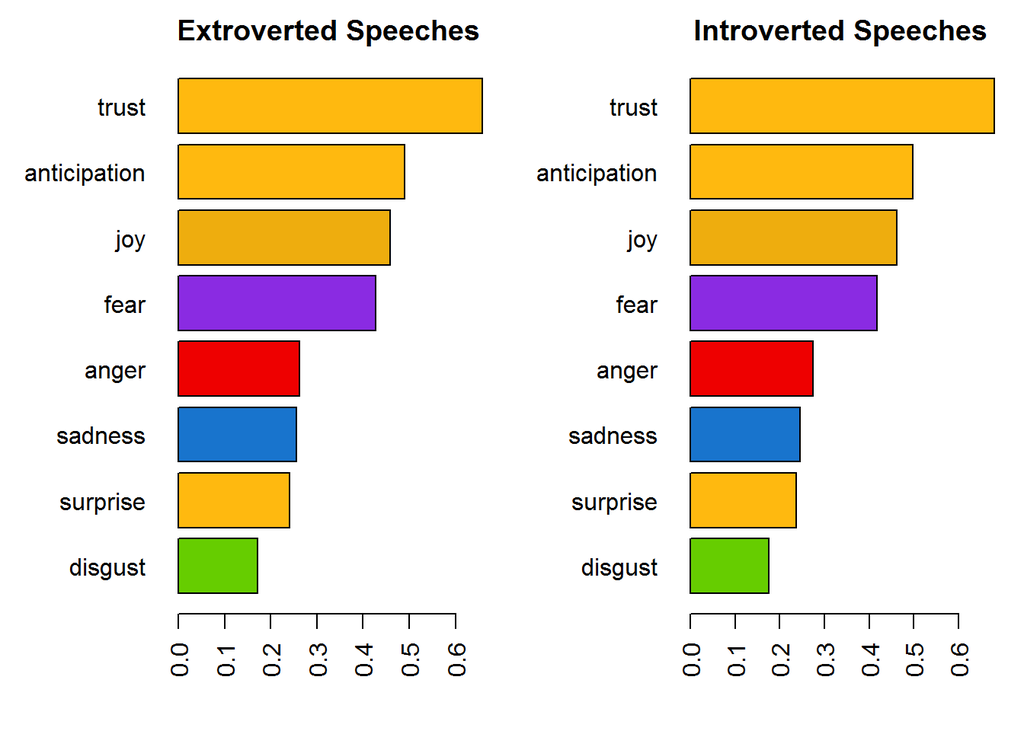

```r
#png('../figs/barchart_emotions.png')

par(mfrow=c(1,2))

par(mar=c(4, 6, 2, 1))
extroverted_emo.means=colMeans(select(extroverted_list, anger:trust)>0.01)
col.use=c("red2", "darkgoldenrod1",
            "chartreuse3", "blueviolet",
            "darkgoldenrod2", "dodgerblue3",
            "darkgoldenrod1", "darkgoldenrod1")
barplot(extroverted_emo.means[order(extroverted_emo.means)], las=2, col=col.use[order(extroverted_emo.means)], horiz=T, main="Extroverted Speeches")

introverted_emo.means=colMeans(select(introverted_list, anger:trust)>0.0)
col.use=c("red2", "darkgoldenrod1",
            "chartreuse3", "blueviolet",
            "darkgoldenrod2", "dodgerblue3",
            "darkgoldenrod1", "darkgoldenrod1")
barplot(introverted_emo.means[order(introverted_emo.means)], las=2, col=col.use[order(introverted_emo.means)], horiz=T, main="Introverted Speeches")
```

It seems they have little difference over using the positive and negative words.

What about under some pressure like an economic recession?

What are the most used terms in an economic recession?

## Compare of extroverted/introverted presidents’ emotions under economic recession

```r
extroverted_recession=sentence.list[sentence.list$personality==1&sentence.list$recession==1,]
introverted_recession=sentence.list[sentence.list$personality==-1&sentence.list$recession==1,]
```

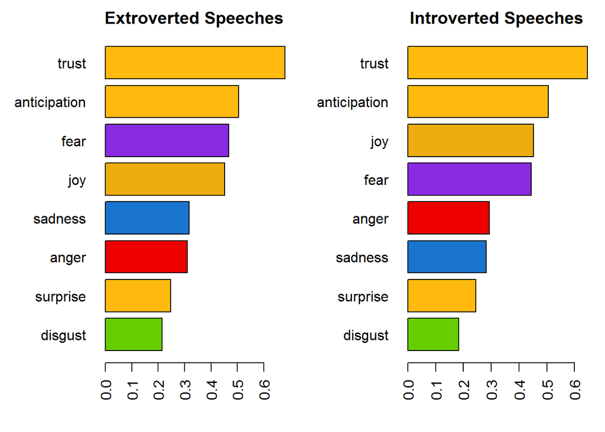

```r
#png('../figs/barchart_emotions.png')

par(mfrow=c(1,2))

par(mar=c(4, 6, 2, 1))
extroverted_emo.means=colMeans(select(extroverted_recession, anger:trust)>0.01)
col.use=c("red2", "darkgoldenrod1",
            "chartreuse3", "blueviolet",
            "darkgoldenrod2", "dodgerblue3",
            "darkgoldenrod1", "darkgoldenrod1")
barplot(extroverted_emo.means[order(extroverted_emo.means)], las=2, col=col.use[order(extroverted_emo.means)], horiz=T, main="Extroverted Speeches")

introverted_emo.means=colMeans(select(introverted_recession, anger:trust)>0.01)
col.use=c("red2", "darkgoldenrod1",
            "chartreuse3", "blueviolet",
            "darkgoldenrod2", "dodgerblue3",
            "darkgoldenrod1", "darkgoldenrod1")
barplot(introverted_emo.means[order(introverted_emo.means)], las=2, col=col.use[order(introverted_emo.means)], horiz=T, main="Introverted Speeches")
```

Extroverted presidents put fear before joy under economic recession. That may suggest an extroverted person like to motative or influence people when there is a pressure.

# Section 3: Topic modeling for extroverted presidents during economic recession.

## Extroverted presidents in recession

For topic modeling, we prepare a corpus of sentence snipets as follows. For each speech, we start with sentences and prepare a snipet with a given sentence with the flanking sentences.

```r
corpus.list=extroverted_recession[2:(nrow(extroverted_recession)-1), ]
sentence.pre=extroverted_recession$sentences[1:(nrow(extroverted_recession)-2)]
sentence.post=extroverted_recession$sentences[3:(nrow(extroverted_recession)-1)]
corpus.list$snipets=paste(sentence.pre, corpus.list$sentences, sentence.post, sep=" ")
rm.rows=(1:nrow(corpus.list))[corpus.list$sent.id==1]
rm.rows=c(rm.rows, rm.rows-1)
corpus.list=corpus.list[-rm.rows, ]
```

### Text mining

```r
docs <- Corpus(VectorSource(corpus.list$snipets))
writeLines(as.character(docs[[sample(1:nrow(corpus.list), 1)]]))
```

```
## To-day the executive branch of the Government is transferred to new keeping. But this is still the Government of all the people, and it should be none the less an object of their affectionate solicitude. At this hour the animosities of political strife, the bitterness of partisan defeat, and the …
```

### Text basic processing

Adapted from https://eight2late.wordpress.com/2015/09/29/a-gentle-introduction-to-topic-modeling-using-r/.

```r
#remove potentially problematic symbols
docs <-tm_map(docs,content_transformer(tolower))

#remove punctuation
docs <- tm_map(docs, removePunctuation)

#Strip digits
docs <- tm_map(docs, removeNumbers)

#remove stopwords
docs <- tm_map(docs, removeWords, stopwords("english"))

meaningless <- c("all","can","say","one","way","use","also","howev","tell","will"
                ,"much","need","take","tend","even","like","particular","rather","said","get"
                ,"well","make","ask","come","end","first","two","often","may","might",
                "see","someth","thing","point","post","look","right","now","think","anoth","yes",
                "day","quit","sinc","attempt","bit","entir","lot","must","shall","from","are","its","not",
                "our","that","the","their","this","which","with")
docs <- tm_map(docs, removeWords, meaningless)

#remove whitespace
docs <- tm_map(docs, stripWhitespace)

#Stem document
docs <- tm_map(docs,stemDocument)
```

### Topic modeling

Gengerate document-term matrices.

```r
dtm <- DocumentTermMatrix(docs)
#convert rownames to filenames#convert rownames to filenames
rownames(dtm) <- paste(corpus.list$type, corpus.list$File,
                       corpus.list$Term, corpus.list$sent.id, sep="_")

rowTotals <- apply(dtm , 1, sum) #Find the sum of words in each Document

dtm  <- dtm[rowTotals> 0, ]
corpus.list=corpus.list[rowTotals>0, ]
```

### Run LDA

```r
#Set parameters for Gibbs sampling
burnin <- 4000
iter <- 2000
thin <- 500
seed <-list(2003,5,63,100001,765)
nstart <- 5
best <- TRUE

#Number of topics
k <- 15

#Run LDA using Gibbs sampling
ldaOut <-LDA(dtm, k, method="Gibbs", control=list(nstart=nstart,
                                                 seed = seed, best=best,
                                                 burnin = burnin, iter = iter,
                                                 thin=thin))
```

```r
#write out results
#docs to topics
ldaOut.topics <- as.matrix(topics(ldaOut))
table(c(1:k, ldaOut.topics))
```

```
##
##   1   2   3   4   5   6   7   8   9  10  11  12  13  14  15
##  54 102  79  76  69 126  57  79  54  73  57  79  79  99  54
```

```r
#write.csv(ldaOut.topics,file=paste("../out/LDAGibbs",k,"DocsToTopics.csv"))

#top 6 terms in each topic
ldaOut.terms <- as.matrix(terms(ldaOut,20))
#write.csv(ldaOut.terms,file=paste("../out/LDAGibbs",k,"TopicsToTerms.csv"))

#probabilities associated with each topic assignment
topicProbabilities <- as.data.frame(ldaOut@gamma)
#write.csv(topicProbabilities,file=paste("../out/LDAGibbs",k,"TopicProbabilities.csv"))
```

```r
terms.beta=ldaOut@beta
terms.beta=scale(terms.beta)
topics.terms=NULL
for(i in 1:k){
  topics.terms=rbind(topics.terms, ldaOut@terms[order(terms.beta[i,], decreasing = TRUE)[1:7]])
}
topics.terms
```

```
##       [,1]        [,2]      [,3]         [,4]         [,5]
##  [1,] "measur"    "error"   "proclaim"   "prepar"     "month"
##  [2,] "believ"    "togeth"  "capac"      "disast"     "era"
##  [3,] "foreign"   "cours"   "neighbor"   "settlement" "washington"
##  [4,] "privileg"  "inde"    "path"       "depriv"     "district"
##  [5,] "prevent"   "price"   "accumul"    "oppress"    "beget"
##  [6,] "work"      "profit"  "hero"       "cost"       "answer"
##  [7,] "past"      "extens"  "north"      "west"       "everywher"
##  [8,] "oath"      "respons" "fulli"      "humbl"      "guid"
##  [9,] "territori" "vast"    "understood" "decid"      "navi"
## [10,] "legisl"    "local"   "hous"       "judiciari"  "enlighten"
## [11,] "love"      "like"    "beauti"     "sink"       "decay"
## [12,] "treasuri"  "sound"   "surplus"    "taxat"      "loan"
## [13,] "depart"    "appear"  "exercis"    "branch"     "mode"
## [14,] "hope"      "face"    "children"   "endur"      "leadership"
```

[output cut: 17 more lines]

```r
ldaOut.terms
```

```
##       Topic 1      Topic 2     Topic 3         Topic 4      Topic 5
##  [1,] "confid"     "govern"    "nation"        "citizen"    "peopl"
##  [2,] "upon"       "good"      "great"         "institut"   "american"
##  [3,] "measur"     "believ"    "peac"          "subject"    "public"
##  [4,] "made"       "men"       "world"         "american"   "govern"
##  [5,] "mani"       "without"   "respect"       "never"      "interest"
##  [6,] "opinion"    "chang"     "polici"        "free"       "demand"
##  [7,] "still"      "individu"  "foreign"       "right"      "civil"
##  [8,] "carri"      "life"      "relat"         "form"       "busi"
##  [9,] "understand" "econom"    "histori"       "principl"   "labor"
## [10,] "principl"   "democraci" "justic"        "member"     "economi"
## [11,] "far"        "problem"   "honor"         "enjoy"      "everi"
## [12,] "adopt"      "alway"     "fellowcitizen" "domest"     "care"
## [13,] "greatest"   "among"     "sinc"          "equal"      "use"
## [14,] "exist"      "order"     "cours"         "possess"    "industri"
```

[output cut: 48 more lines]

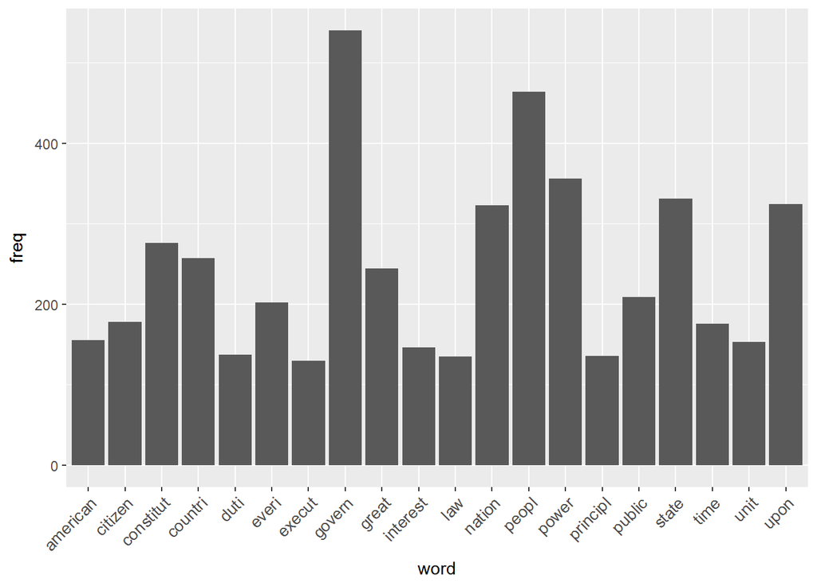

```r
freq <- sort(colSums(as.matrix(dtm)))

wf <- data.frame(word=names(freq),freq=freq)

freq2 <- colSums(as.matrix(dtm))

p_e <- ggplot(subset(tail(wf,20),freq>50),aes(word,freq))
p_e <- p_e+geom_bar(stat = "identity")
p_e <- p_e+theme(axis.text.x = element_text(angle = 45,hjust = 1,size = 10))
p_e
```

The most common words that extroverted president used during an economic recession.